# Amir_Ali_SNARS_3

[figure not shown]

In this project, Work with different ditribution, Empirical justification, and some Graph visualization methods which is main part of this assignment.

`Note`: Task is perform using Python

[figure not shown]

### Part 1: Import the Libraries

```python
import warnings
import numpy as np
import networkx as nx
from scipy.io import mmread
from celluloid import Camera
import matplotlib.pyplot as plt
from scipy.spatial import distance_matrix

plt.style.use('fivethirtyeight')
warnings.filterwarnings('ignore')
```

[figure not shown]

## Excercise 1

Draw a histogram with marked sigma intervals for random variables from the normal distribution

```python
n=1000
```

```python
X=np.random.normal(size=n)
```

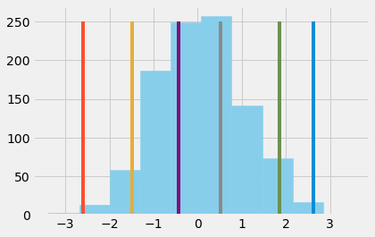

```python
plt.hist(X, color = "skyblue", ec="skyblue")
plt.plot([np.quantile(X,0.997),np.quantile(X,0.997)],[0,250])
plt.plot([np.quantile(X,1-0.997),np.quantile(X,1-0.997)],[0,250])
plt.plot([np.quantile(X,1-0.95),np.quantile(X,1-0.95)],[0,250])
plt.plot([np.quantile(X,0.95),np.quantile(X,0.95)],[0,250])
plt.plot([np.quantile(X,0.68),np.quantile(X,0.68)],[0,250])
plt.plot([np.quantile(X,1-0.68),np.quantile(X,1-0.68)],[0,250])
plt.show()
```

[figure not shown]

## Excercise 2

Check the Pareto rule for variables from the geometric distribution

```python
X=np.random.geometric(0.5,size=n)
```

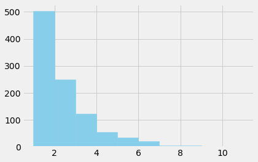

```python
plt.hist(X, color = "skyblue", ec="skyblue")
plt.show()
```

```python
np.sum(X[X>=np.quantile(X,0.8)])/np.sum(X)   # 0.8/ all
```

```
0.4992548435171386
```

[figure not shown]

## Excercise 3

Draw a histogram with marked sigm intervals for variables drawn from a continuous power distribution

```python
X=np.random.power(5,size=n)
```

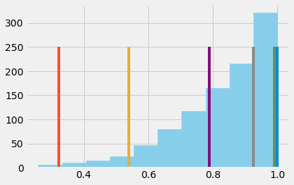

```python
plt.hist(X, color = "skyblue", ec="skyblue")
plt.plot([np.quantile(X,0.997),np.quantile(X,0.997)],[0,250])
plt.plot([np.quantile(X,1-0.997),np.quantile(X,1-0.997)],[0,250])
plt.plot([np.quantile(X,1-0.95),np.quantile(X,1-0.95)],[0,250])
plt.plot([np.quantile(X,0.95),np.quantile(X,0.95)],[0,250])
plt.plot([np.quantile(X,0.68),np.quantile(X,0.68)],[0,250])
plt.plot([np.quantile(X,1-0.68),np.quantile(X,1-0.68)],[0,250])
plt.show()
```

[figure not shown]

## Excercise 4

Check the Pareto rule for variables from the zeta distribution

```python
X=np.random.zipf(2,size=n)
```

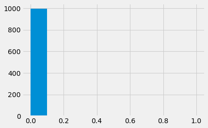

```python
plt.hist(X/max(X))
plt.show()
```

```python
np.sum(X[X>=np.quantile(X,0.8)])/np.sum(X)
```

```
0.790114780979152
```

[figure not shown]

## Excercise 5

Empirical justification

#### BA network

```python
BA = nx.generators.barabasi_albert_graph(20, 5, seed=123)
```

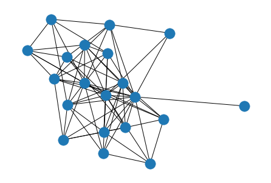

```python
nx.draw(BA)
```

```python
deg = nx.degree_histogram(BA)
```

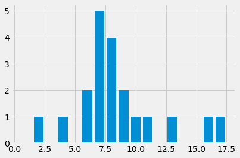

```python
plt.bar(x=np.linspace(1,len(deg),len(deg)),height=np.array(deg))   # # vertex degree histogram
plt.show()
```

```python
d=np.concatenate([np.array([i]*deg[i]) for i in range(len(deg))])
np.var(d)
```

```
12.25
```

```python
np.mean(d)
```

```
7.5
```

#### ER netowrk

```python
GER = nx.generators.erdos_renyi_graph(20, 0.25, seed=123)
```

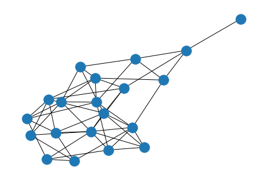

```python
nx.draw(GER)
```

```python
deg=nx.degree_histogram(GER)
```

[output not shown]

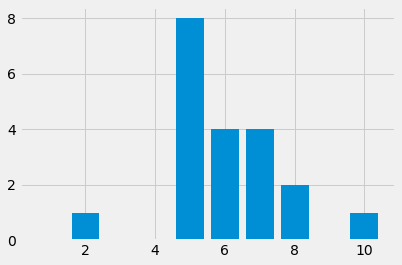

```python
plt.bar(x=np.linspace(1,len(deg),len(deg)),height=np.array(deg))
```

```python
d=np.concatenate([np.array([i]*deg[i]) for i in range(len(deg))])
np.var(d)
```

```
2.6
```

```python
np.mean(d)
```

```
5.0
```

#### BA vs ER

So fundamentally, they are created in different ways:

In the Erdos-Renyi network, we assign N nodes, and then connect each pair with probability p. This means that no one node will have much higher degree than any other.

In the B-A network, we assign N nodes, but to create them, we first start with a small set of connected nodes. Then we add nodes one at a time till we get N nodes. When we add a node, we connect it to a small number of existing nodes with probability proportional to the degree of the existing node. As a result, nodes with higher degree (the earlier ones) tend to get even higher degree.

[figure not shown]

## Excercise P3.1

Read documentation of the pre-defined graph layout functions in your chosen environment. For the selected real graph, test several visualization methods.

#### road chesapeake dataset

This network dataset is in the category of Road Networks  
https://networkrepository.com/road-chesapeake.php

```python
G = mmread('road-chesapeake.mtx')

G = G.todense()

G = np.matrix(G)

G=nx.Graph(G)
```

#### Spring Layout

The nodes in the graph are positioned as if they are connected by springs and their final positions determined by a minimum of stretching of the edges.

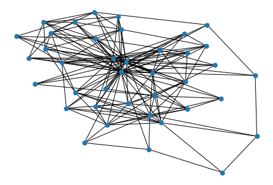

```python
positions_G = nx.spring_layout(G)
nx.draw(G,pos=positions_G,node_size=50)
```

#### Shell Layout

Position nodes in concentric circles.

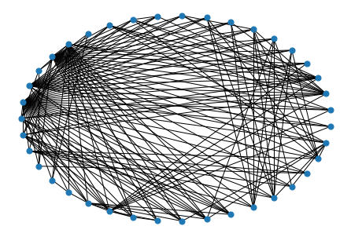

```python
positions_G = nx.shell_layout(G)
nx.draw(G,pos=positions_G,node_size=50)
```

#### Circular Layout

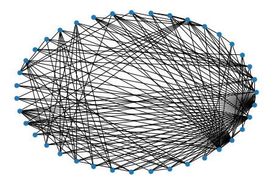

```python
positions_G = nx.circular_layout(G)
nx.draw(G,pos=positions_G,node_size=50)
```

#### Spectral Layout

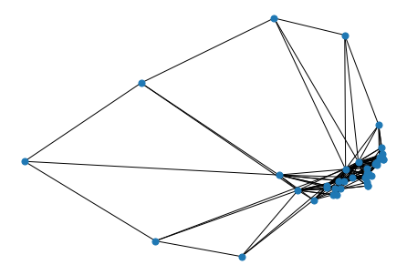

```python
positions_G = nx.spectral_layout(G)
nx.draw(G,pos=positions_G,node_size=50)
```

#### Spiral Layout

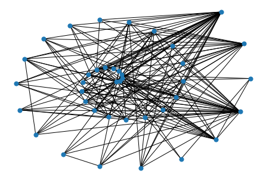

```python
positions_G = nx.spiral_layout(G)
nx.draw(G,pos=positions_G,node_size=50)
```

#### Kamada Kawai Layout

Kamada-Kawai graph layout attempts to position nodes on the space so that the geometric (Euclidean) distance between them is as close as possible to the graph-theoretic (path) distance between them

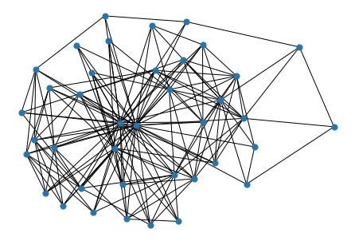

```python
positions_G = nx.kamada_kawai_layout(G)
nx.draw(G,pos=positions_G,node_size=50)
```

[figure not shown]

## Excercise P3.3

Implement the graph visualization based on the spring method

```python
G=nx.generators.graph_atlas(100)
```

```python
A = nx.adjacency_matrix(G)

A=A.todense()

A=np.array(A)
```

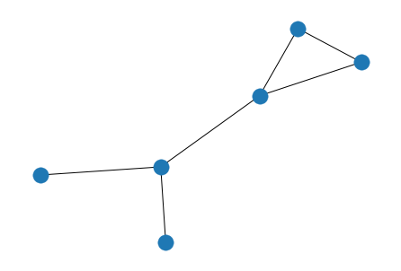

```python
positions_G = nx.spring_layout(G)
nx.draw(G,pos=positions_G)
```

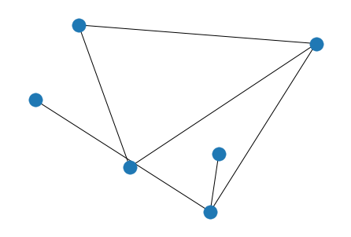

```python
positions_G = nx.random_layout(G,seed=123)
nx.draw(G,pos=positions_G)
```

```python
Q2=1

K=1

alpha=0.0005

epoch=100
```

```python
#fig = plt.figure()
#camera = Camera(fig)

for i in range(epoch):
    pos=np.array([positions_G[i] for i in range(len(A))])

    dist=distance_matrix(pos,pos)

    dist_inv = np.divide(1, dist, out=np.zeros_like(dist), where=dist!=0)

    vect = np.ones([len(pos),len(pos),2])
    for i in range(len(pos)):
        for j in range(len(pos)):
            vect[i,j,:] = np.subtract(pos[i], pos[j])

    vectx_elec=np.dot(vect[:,:,0],dist_inv*dist_inv)

    vecty_elec=np.dot(vect[:,:,1],dist_inv*dist_inv)

    vectxy_elec=np.concatenate((vectx_elec[:,np.newaxis], vecty_elec[:,np.newaxis]), axis=1).transpose([0,2,1])

    vect_elec_final=np.sum(vectxy_elec,axis=0)*Q2

    vectx_spring=np.dot(vect[:,:,0],np.multiply(A,dist))

    vecty_spring=np.dot(vect[:,:,1],np.multiply(A,dist))

    vectxy_spring=np.concatenate((vectx_spring[:,np.newaxis], vecty_spring[:,np.newaxis]), axis=1).transpose([0,2,1])

    vect_spring_final=np.sum(vectxy_spring,axis=0)*K

    for i in range(len(A)):
        positions_G[i]=positions_G[i]+alpha*(vect_elec_final[i]-vect_spring_final[i])

    #nx.draw(G,pos=positions_G)
    #camera.snap()

#animation = camera.animate()
#animation.save('graph.gif', writer = 'imagemagick')
```

```python
positions_G
```

```
{0: array([0.81239878, 0.23590629]),
 1: array([0.32542168, 0.49146353]),
 2: array([0.7176189 , 0.69484749]),
 3: array([1.02940015, 0.7008617 ]),
 4: array([0.63371252, 0.52385696]),
 5: array([0.52187349, 0.97578559])}
```

```python
#fig = plt.figure()
#camera = Camera(fig)

for i in range(epoch):
    pos=np.array([positions_G[i] for i in range(len(A))])

    dist=distance_matrix(pos,pos)

    dist_inv = np.divide(1, dist, out=np.zeros_like(dist), where=dist!=0)

    vect = np.ones([len(pos),len(pos),2])
    for i in range(len(pos)):
        for j in range(len(pos)):
            vect[i,j,:] = np.subtract(pos[i], pos[j])

    vectx_elec=np.dot(vect[:,:,0],dist_inv*dist_inv)

    vecty_elec=np.dot(vect[:,:,1],dist_inv*dist_inv)

    vectxy_elec=np.concatenate((vectx_elec[:,np.newaxis], vecty_elec[:,np.newaxis]), axis=1).transpose([0,2,1])

    vect_elec_final=np.sum(vectxy_elec,axis=0)*Q2

    vectx_spring=np.dot(vect[:,:,0],np.multiply(A,dist))

    vecty_spring=np.dot(vect[:,:,1],np.multiply(A,dist))

    vectxy_spring=np.concatenate((vectx_spring[:,np.newaxis], vecty_spring[:,np.newaxis]), axis=1).transpose([0,2,1])

    vect_spring_final=np.sum(vectxy_spring,axis=0)*K

    for i in range(len(A)):
        positions_G[i]=positions_G[i]+alpha*(vect_elec_final[i]-vect_spring_final[i])

    #nx.draw(G,pos=positions_G)
    #camera.snap()

#animation = camera.animate()
#animation.save('graph.gif', writer = 'imagemagick')
```

```python
positions_G
```

```
{0: array([ 1.3194732 , -0.52668476]),
 1: array([ 0.14794543, -0.69865576]),
 2: array([0.90620419, 0.09250743]),
 3: array([1.72121518, 0.69251364]),
 4: array([0.67870003, 0.73622796]),
 5: array([1.02278795, 1.35273676])}
```

```python
vect_elec_final-vect_spring_final
```

```
array([[ 1.89914369, -3.05577794],
       [ 0.93480438, -4.40039808],
       [ 0.90078667, -2.45957926],
       [ 2.63868511, -1.29963956],
       [ 1.92914714, -0.85321635],
       [ 2.31366431, -0.71698668]])
```

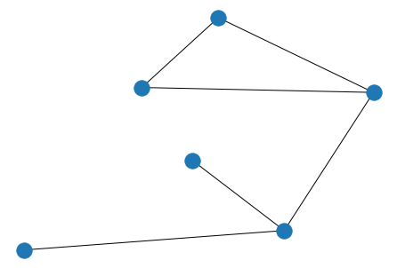

```python
nx.draw(G,pos=positions_G)
```

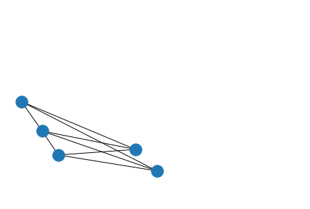

```python
from matplotlib import pyplot as plt
from celluloid import Camera

fig = plt.figure()
camera = Camera(fig)
for i in range(10):
    positions_G = nx.random_layout(G,seed=i)
    nx.draw(G,pos=positions_G)
    camera.snap()
animation = camera.animate()
animation.save('celluloid_minimal.gif', writer = 'imagemagick')
```

[figure not shown]